# Unimodal functions and multi-species SDMs using mixed-effects models

Petr Keil

October 6, 2017

Here I attempt to clarify some ideas that we discussed with Duarte Viana today. The material will probably seem a bit random to a random reader.

# 1 How does a parabola on a log scale look on a linear scale?

Let’s consider an `Env` variable representing a gradient of an environmental condition. We can model logarithm of abundance (`log_Abund`) as a regular parabola (2nd-degree polynomial):
$$\log Abund = 2Env - 4Env^2$$

```r
  Env <- seq(-2, 2, by = 0.1)
  log_Abund <- 2*Env - 4*(Env^2)
```

Now we can plot the abunance on both logarithmic and linear scale. We can see that what we modelled as a parabola going all the way down to -20, is actually a bell-shaped curve on the linear scale:

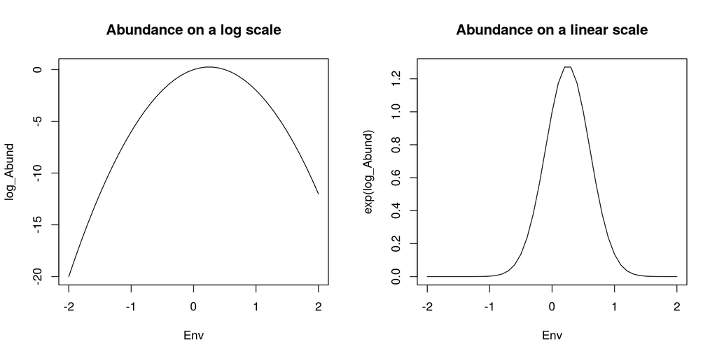

```r
  par(mfrow=c(1,2))
  plot(Env, log_Abund, type="l", main="Abundance on a log scale")
  plot(Env, exp(log_Abund), type="l", main="Abundance on a linear scale")
```

**Lesson:** Polynomial **GLMs (and related models) with log-link function** can indeed be used to model non-linear unimodal responses of species to environment. The same logic applies for **logit link functions**, e.g. in models for binomially distributed data.

# 2 Can the 2nd-degree polynomial fit a very narrow responses?

Is a parabola fitted on the log scale flexible enough to fit extremely narrow species responses to environment, where the species is missing from most of the gradient?

Here I manually generate a species with a very narrow niche, and with a lots of zeroes in the data:

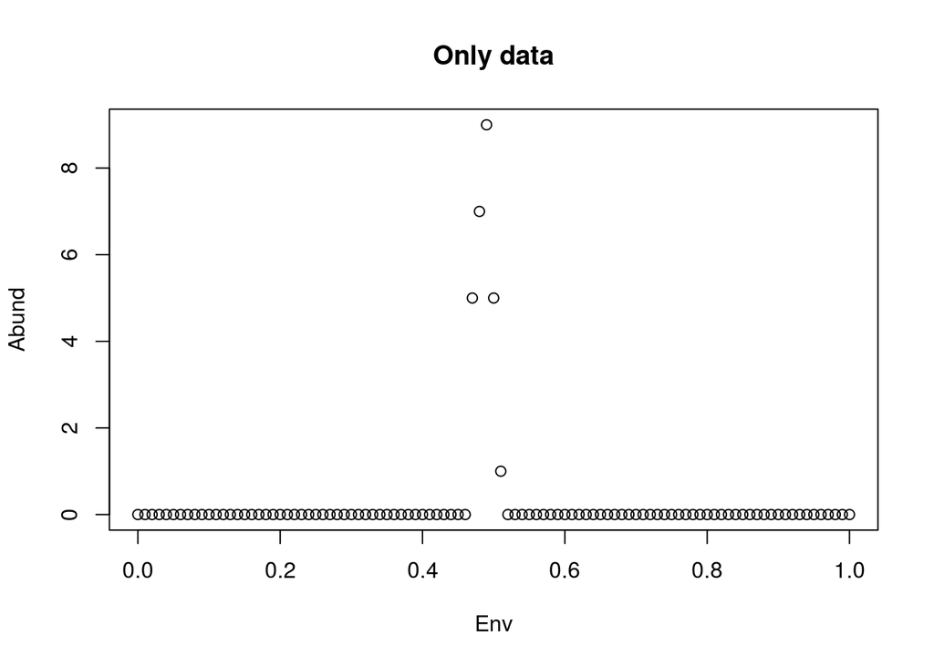

```r
  Env <- seq(0, 1, by = 0.01)
  Abund <- rep(0, times = length(Env))
  Abund[c(48:52)] <- c(5, 7, 9, 5, 1)
  plot(Env, Abund, main="Only data")
```

Here I fit the parabola using `glm`; setting the family to `"poisson"` automatically invokeslog link function:

```r
  m1 <- glm(Abund~poly(Env,2), family="poisson")
```

And this is how the fitted model looks like:

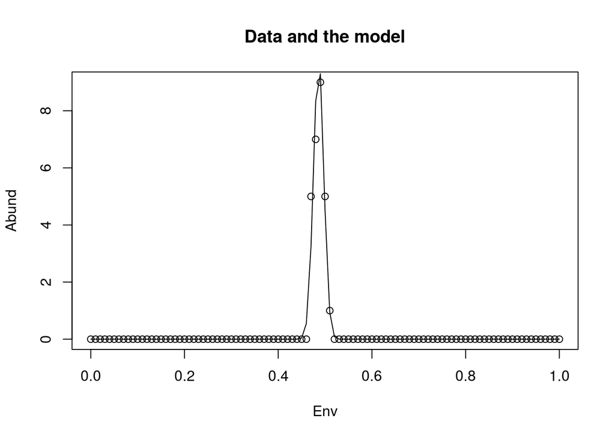

```r
  plot(Env, Abund, main="Data and the model")
  lines(Env, predict(m1, type="response"))
```

**Lesson:** Even very simple polynomial GLMs can very well describe responses of species with very narrow optima along an environmental gradients.

# 3 Multi-species mixed-effects SDM in lme4

Here I will use the `vegan` dataset `mite` to show how a simple multi-species SDM can be done.

```r
  library(vegan)
  library(lme4)
  library(tidyr)
  library(ggplot2)
```

## 3.1 Prepare the data

```r
  data(mite)
  data(mite.env)
  data(mite.xy)

  X <- data.frame(mite.xy, SubsDens = mite.env$SubsDens, mite)
  head(X)
```

```
##     x   y SubsDens Brachy PHTH HPAV RARD SSTR Protopl MEGR MPRO TVIE HMIN
## 1 0.2 0.1    39.18     17    5    5    3    2       1    4    2    2    1
## 2 1.0 0.1    54.99      2    7   16    0    6       0    4    2    0    0
## 3 1.2 0.3    46.07      4    3    1    1    2       0    3    0    0    0
## 4 1.4 0.5    48.19     23    7   10    2    2       0    4    0    1    2
## 5 2.4 0.7    23.55      5    8   13    9    0      13    0    0    0    3
## 6 1.8 0.9    57.32     19    7    5    9    3       2    3    0    0   20
##   HMIN2 NPRA TVEL ONOV SUCT LCIL Oribatl1 Ceratoz1 PWIL Galumna1 Stgncrs2
## 1     4    1   17    4    9   50        3        1    1        8        0
## 2     1    3   21   27   12  138        6        0    1        3        9
## 3     6    3   20   17   10   89        3        0    2        1        8
## 4    10    0   18   47   17  108       10        1    0        1        2
## 5    14    3   32   43   27    5        1        0    5        2        1
## 6    16    2   13   38   39    3        5        0    1        1        8
##   HRUF Trhypch1 PPEL NCOR SLAT FSET Lepidzts Eupelops Miniglmn LRUG PLAG2
## 1    0        0    0    0    0    0        0        0        0    0     0
## 2    1        1    1    2    2    2        1        0        0    0     0
## 3    0        3    0    2    0    8        0        0        0    0     0
## 4    1        2    1    3    2   12        0        0        0    0     0
## 5    0        1    0    0    0   12        2        0        0    0     0
## 6    0        4    0    1    0   10        0        0        0    0     0
##   Ceratoz3 Oppiminu Trimalc2
## 1        0        0        0
## 2        0        0        0
## 3        0        0        0
## 4        0        0        0
## 5        0        0        0
## 6        0        0        0
```

I need to rearrange the data from the site X specie matrix to a long format using the `gather` function from `tidyr`:

```r
 mite.long <- gather(data=X, species=colnames(mite), factor_key=TRUE)
 names(mite.long)[4:5] <- c("species","N")
 head(mite.long)
```

```
##     x   y SubsDens species  N
## 1 0.2 0.1    39.18  Brachy 17
## 2 1.0 0.1    54.99  Brachy  2
## 3 1.2 0.3    46.07  Brachy  4
## 4 1.4 0.5    48.19  Brachy 23
## 5 2.4 0.7    23.55  Brachy  5
## 6 1.8 0.9    57.32  Brachy 19
```

I will scale the continual predictor in the data to 0 mean and unit variance:

```r
  mite.long$SubsDens <- scale(mite.long$SubsDens )
```

## 3.2 Fit the mixed-effect models

I will fit two models, each of them with varying slopes and varying intercepts, one with a linear response, the other with a polynomial response to the environment (substrate density `SubsDens`):

```r
m.lin <- glmer(N ~ SubsDens + (1 + SubsDens|species),
               data=mite.long, family="poisson")

m.poly <- glmer(N ~ poly(SubsDens,degree=2) + (1 + poly(SubsDens, degree=2)|species),
                data=mite.long, family="poisson")
```

## 3.3 Extract model predictions

```r
  preds <- data.frame(mite.long, preds=predict(m.poly, type="response"))
```

## 3.4 Plot the predictions

### 3.4.1 Log scale

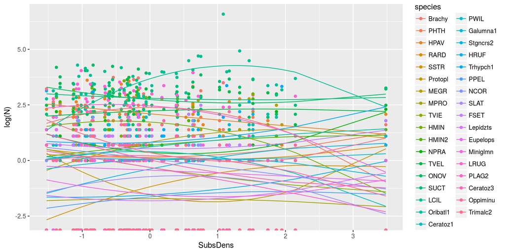

```r
  ggplot(data=preds, aes(x=SubsDens, y=log(N))) +
    geom_point(aes(colour=species)) +
    geom_line( aes(x=SubsDens, y=log(preds), colour=species) )
```

### 3.4.2 Linear scale

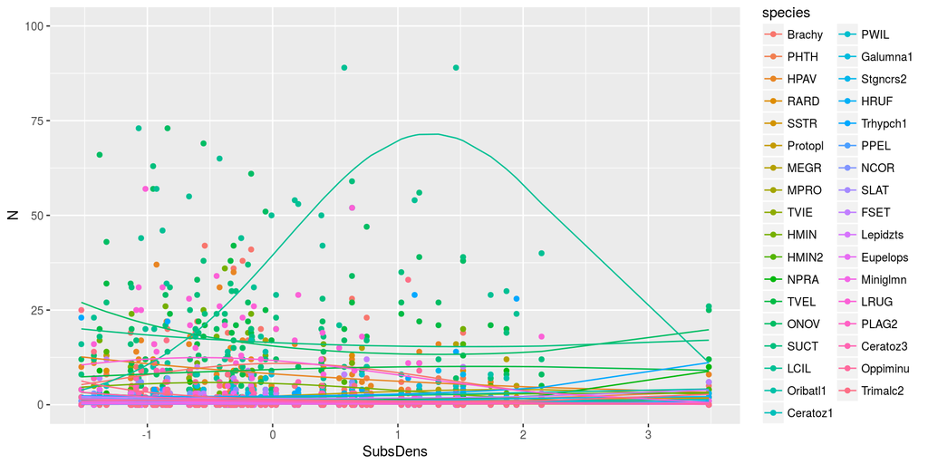

```r
  ggplot(data=preds, aes(x=SubsDens, y=N)) +
    geom_point(aes(colour=species)) +
    geom_line( aes(x=SubsDens, y=preds, colour=species) ) +
    ylim(c(0,100))
```